https://russianblogs.com/article/31021630745/

# Как настроить среду разработки языка C_C ++ в Notepad ++

Я считаю, что многие люди используют notepad ++, но нужно немного подбросить, чтобы настроить его как C / C ++. Я долго искал в Интернете, и нет единого ответа, и методы, которые многие люди говорят, совершенно бесполезны, и они недостаточно универсальны, поэтому я исследовал их сам и поделился со всеми.

Нечего сказать, начнем настройку.

1/8

Скачайте и установите Notepad ++, этот шаг не повторится.

2/8

Установите minGW (или скопируйте папку minGW, лично считаю, что не имеет значения, установлен он или нет, это не влияет на использование) на диск C (другие диски также приемлемы, вот диск C в качестве примера ).

После завершения измените имя папки minGW на диске C на MinGW64.

Если вы хотите установить minGW, перейдите по ссылке, чтобы узнать, как его установить (если вы хотите, просто установите его, я не знаю, как).

[figure not shown]

3/8

Добавьте "C: \ MinGW64 \ bin" в переменную системного окружения (C: \ MinGW64 - это minGW, который был скопирован или установлен только что, в нем много всего, не беспокойтесь об этом). См. Ссылку, чтобы узнать, как добавить системные переменные среды.

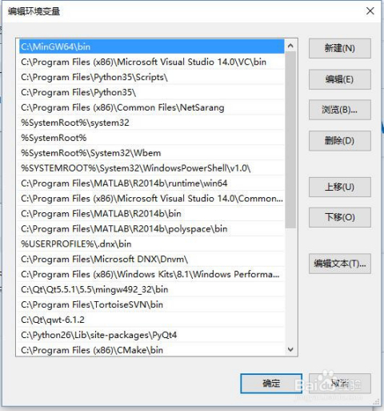

4/8 Проверить, может ли система найти компилятор.

"win key + R", введите "cmd", нажмите Enter для подтверждения, вызовите окно команды dos, введите: g ++ -v, обратите внимание, что между g ++ и -v есть пробел, нажмите Enter, вы должны увидеть картинку как показано Сообщение указывает, что mingw готов к работе. Красная часть указывает на используемую версию mingw, я использовал mingw 5.3.0.

Если он показывает, что g ++ не является внутренней командой или аналогичным запросом, вы можете перезапустить и попробовать снова (это не должно быть большой проблемой после правильного добавления переменных среды).

[figure not shown]

[figure not shown]

5/8 Начнем со следующего:

Откройте блокнот ++, нажмите F5 или щелкните строку меню «Выполнить -> Выполнить», появится следующее диалоговое окно, введите:

```
cmd /k cd /d "$(CURRENT_DIRECTORY)" & g++ "$(FILE_NAME)" -o "$(NAME_PART)" & "$(NAME_PART).exe"
```

Затем нажмите «Сохранить».

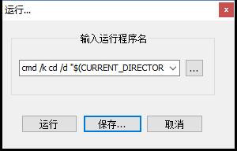

6/8 После нажатия кнопки «Сохранить» появится следующее диалоговое окно. Задайте имя и ярлык для этой команды. Например, введите «C / C ++ compiler» в качестве имени и установите ярлык (ярлык) в соответствии с вашей привычкой. Нажмите «ОК», и все готово.

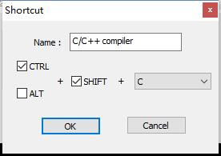

[output not shown]

[figure not shown]

[figure not shown]